```python
!pip install -q numpy==1.19.5 matplotlib==3.3.3 pandas==1.2.1 scikit-image==0.18.1 scipy==1.6.0
```

```python
import numpy as np
import pandas as pd
import matplotlib.pyplot as plt
import scipy.signal as dsp
import scipy.fftpack as fft
import skimage as img
import IPython.display as ipd
```

# Image Representation and Spectral Resolution

The human visual system is based on three bands of color: Red, Green, and Blue. As a result, computer screens are designed as three color displays. This can be confirmed by rendering a color-wheel that contains all the colors within the spectral resolution of the human eye (and the dynamic range of the pixel format) and separately visualizing the Red, Green, and Blue channels of the digital image.

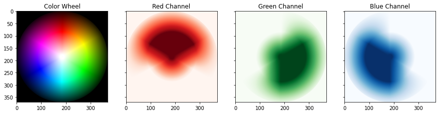

```python
IMG = img.data.colorwheel()
fig, (ax1, ax2, ax3, ax4) = plt.subplots(1, 4, figsize=(15, 5), sharey=True)
# original color wheel
ax1.imshow(IMG)
ax1.set_title('Color Wheel')
# the red channel
ax2.imshow(IMG[:, :, 0], cmap='Reds')
ax2.set_title('Red Channel')
# the green channel
ax3.imshow(IMG[:, :, 1], cmap='Greens')
ax3.set_title('Green Channel')
# the blue channel
ax4.imshow(IMG[:, :, 2], cmap='Blues')
ax4.set_title('Blue Channel')
```

# De-Bayering a Digital Image

Most digital cameras use the Bayer pattern to convert the luminance data to digital pixels. This process can be undone by assuming a direct mapping between pixels and their photosensor value.

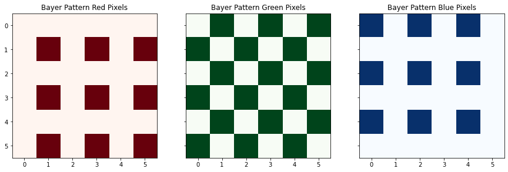

```python
fig, (ax1, ax2, ax3) = plt.subplots(1, 3, figsize=(15, 5), sharey=True)
# red pixels
r = np.zeros((6, 6))
r[1::2,1::2] += 255
ax1.imshow(r, cmap='Reds')
ax1.set_title('Bayer Pattern Red Pixels')
# green pixels
g = 255 * np.ones((6, 6))
g[1::2,1::2] -= 255
g[::2,::2] -= 255
ax2.imshow(g, cmap='Greens')
ax2.set_title('Bayer Pattern Green Pixels')
# blue pixels
b = np.zeros((6, 6))
b[::2,::2] += 255
ax3.imshow(b, cmap='Blues')
ax3.set_title('Bayer Pattern Blue Pixels')
```

Masking filters can be applied to a digital image to estimate how the channels looked on the photosensors that originally captured the image.

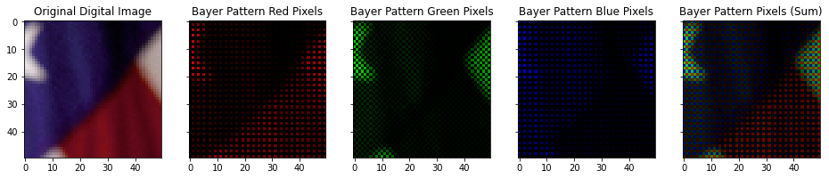

```python
IMG = img.data.astronaut()[100:150, 0:50]
fig, (ax0, ax1, ax2, ax3, ax4) = plt.subplots(1, 5, figsize=(16, 6), sharey=True)
# red filter
REDS = np.zeros_like(IMG)
REDS[1::2,1::2,0] += 255
# green filter
GREENS = 255 * np.ones_like(IMG)
GREENS[1::2,1::2,1] -= 255
GREENS[::2,::2,1] -= 255
GREENS[:, :, 0] = 0
GREENS[:, :, 2] = 0
# blue filter
BLUES = np.zeros_like(IMG)
BLUES[::2,::2,2] += 255
# filter the channels in individual plots
ax0.imshow(IMG)
ax0.set_title('Original Digital Image')
ax1.imshow(IMG[:, :] & REDS)
ax1.set_title('Bayer Pattern Red Pixels')
ax2.imshow(IMG[:, :] & GREENS)
ax2.set_title('Bayer Pattern Green Pixels')
ax3.imshow(IMG[:, :] & BLUES)
ax3.set_title('Bayer Pattern Blue Pixels')
mosaic = (IMG[:, :] & REDS) + (IMG[:, :] & GREENS) + (IMG[:, :] & BLUES)
ax4.imshow(mosaic)
ax4.set_title('Bayer Pattern Pixels (Sum)')
```

# Reducing Mosaicing from Bayer Pattern using Interpolation

As can be seen above, the naive sum of the Bayer pattern channels does not look like the original image. This is because each channel covers only $25\%$ (in the case of red and blue) or $50\%$ (in the case of green) of the pixel space for a channel. This sparsity of pixel coverage causes the effect called *mosaicing*, which can be resolved in a variety of ways.

A naive approach to reduce the mosaicing effect is to replace the empty pixels for each channel with the average of its neighbors.

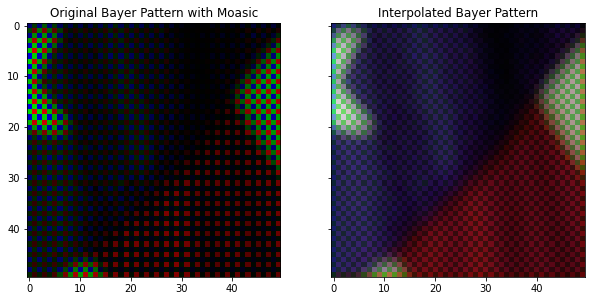

```python
# create a kernel for 2D convolution that computes an average of direct neighbors
kernel1 = np.array([[0,1,0],
                    [1,0,1],
                    [0,1,0]])
# create another kernel for 2D convolution that computes an average of direct and corner neighbors
kernel2 = np.array([[1,1,1],
                    [1,0,1],
                    [1,1,1]])
# create an empty tensor for the interpolated values
interpolated = np.zeros_like(mosaic)
# calculate the interpolation for each of the three channels (use kernel1 magnitude for all channels)
interpolated[:, :, 0] = dsp.convolve2d(mosaic[:, :, 0], kernel2, boundary='fill', mode='same') / kernel1.sum()
interpolated[:, :, 1] = dsp.convolve2d(mosaic[:, :, 1], kernel1, boundary='fill', mode='same') / kernel1.sum()
interpolated[:, :, 2] = dsp.convolve2d(mosaic[:, :, 2], kernel2, boundary='fill', mode='same') / kernel1.sum()
# plot the change in the images
fig, (ax0, ax1) = plt.subplots(1, 2, figsize=(10, 5), sharey=True)
ax0.imshow(mosaic)
ax0.set_title('Original Bayer Pattern with Moasic')
ax1.imshow(mosaic + interpolated)
ax1.set_title('Interpolated Bayer Pattern')
```